# Week 5

*This week we follow through the examples in Exercise Set 5.*

```r
date()
```

```
## [1] "Mon Dec  4 21:53:15 2023"
```

## Analysis

### Step 0

Create this file and include it in `index.Rmd`.

### Step 1

```r
library(readr)
human <- read_csv("data/human.csv", show_col_types = FALSE)
```

> “Move the country names to rownames”

```r
library(tibble)
human <- column_to_rownames(human, "Country")
```

> “Show a graphical overview of the data”

```r
library(GGally)
```

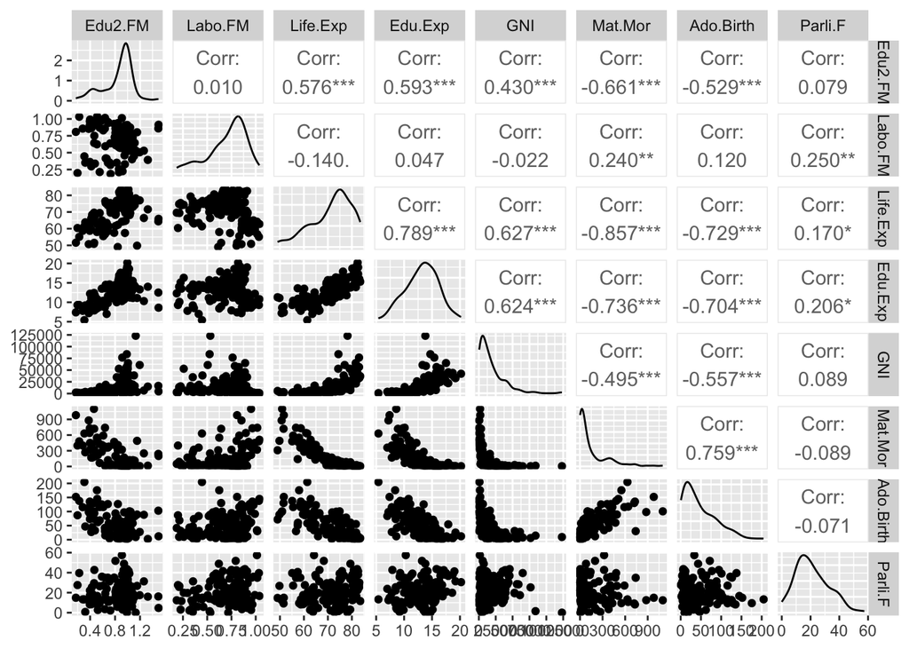

```r
library(ggplot2)
ggpairs(human, progress = FALSE)
```

> “Show summaries of the variables in the data”

```r
summary(human)
```

```
##     Edu2.FM          Labo.FM          Life.Exp        Edu.Exp
##  Min.   :0.1717   Min.   :0.1857   Min.   :49.00   Min.   : 5.40
##  1st Qu.:0.7264   1st Qu.:0.5984   1st Qu.:66.30   1st Qu.:11.25
##  Median :0.9375   Median :0.7535   Median :74.20   Median :13.50
##  Mean   :0.8529   Mean   :0.7074   Mean   :71.65   Mean   :13.18
##  3rd Qu.:0.9968   3rd Qu.:0.8535   3rd Qu.:77.25   3rd Qu.:15.20
##  Max.   :1.4967   Max.   :1.0380   Max.   :83.50   Max.   :20.20
##       GNI            Mat.Mor         Ado.Birth         Parli.F
##  Min.   :   581   Min.   :   1.0   Min.   :  0.60   Min.   : 0.00
##  1st Qu.:  4198   1st Qu.:  11.5   1st Qu.: 12.65   1st Qu.:12.40
##  Median : 12040   Median :  49.0   Median : 33.60   Median :19.30
##  Mean   : 17628   Mean   : 149.1   Mean   : 47.16   Mean   :20.91
##  3rd Qu.: 24512   3rd Qu.: 190.0   3rd Qu.: 71.95   3rd Qu.:27.95
##  Max.   :123124   Max.   :1100.0   Max.   :204.80   Max.   :57.50
```

```r
library(corrplot)
cor(human)
```

```
##                Edu2.FM      Labo.FM   Life.Exp     Edu.Exp         GNI
## Edu2.FM    1.000000000  0.009564039  0.5760299  0.59325156  0.43030485
## Labo.FM    0.009564039  1.000000000 -0.1400125  0.04732183 -0.02173971
## Life.Exp   0.576029853 -0.140012504  1.0000000  0.78943917  0.62666411
## Edu.Exp    0.593251562  0.047321827  0.7894392  1.00000000  0.62433940
## GNI        0.430304846 -0.021739705  0.6266641  0.62433940  1.00000000
## Mat.Mor   -0.660931770  0.240461075 -0.8571684 -0.73570257 -0.49516234
## Ado.Birth -0.529418415  0.120158862 -0.7291774 -0.70356489 -0.55656208
## Parli.F    0.078635285  0.250232608  0.1700863  0.20608156  0.08920818
##              Mat.Mor  Ado.Birth     Parli.F
## Edu2.FM   -0.6609318 -0.5294184  0.07863528
## Labo.FM    0.2404611  0.1201589  0.25023261
## Life.Exp  -0.8571684 -0.7291774  0.17008631
## Edu.Exp   -0.7357026 -0.7035649  0.20608156
## GNI       -0.4951623 -0.5565621  0.08920818
## Mat.Mor    1.0000000  0.7586615 -0.08944000
## Ado.Birth  0.7586615  1.0000000 -0.07087810
## Parli.F   -0.0894400 -0.0708781  1.00000000
```

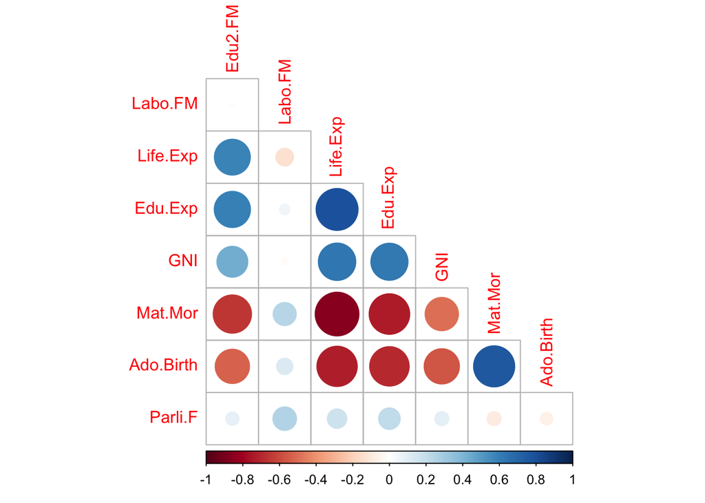

```r
library(corrplot)
correlation_matrix <- cor(human) %>% round(digits = 2)
corrplot(correlation_matrix, method="circle", diag = FALSE, type = 'lower')
```

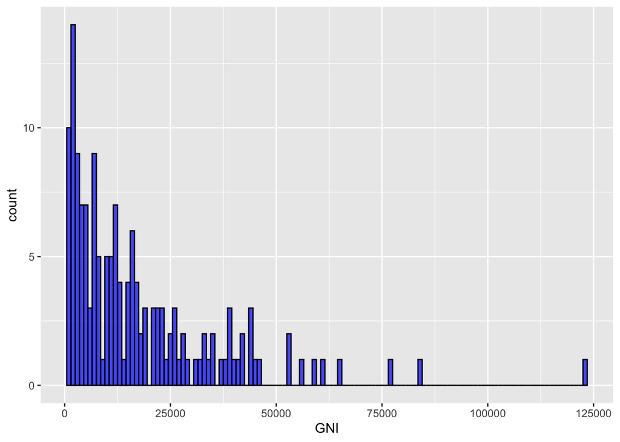

```r
ggplot(human, aes(x = GNI)) +
  geom_histogram(binwidth = 1000, fill = "blue", color = "black", alpha = 0.7)
```

> “Describe and interpret the outputs, commenting on the distributions of the variables and the relationships between them”

What can we say about the distributions of the variables? It is somewhat reminiscent of Hans Rosling’s lectures… And because the hand-picked nature of our basket of variables, it is not surprising the scatter plots show some noticeable patterns. For GNI for example we can see there are a few very rich countries, a bunch of middle-income countries, then many poor countries.

Going from the Rosling perspective (public health and human development), we can see for example that Life Expectancy and Maternal Mortality are strongly correlated, with both being influence by health infrastructure etc. Life Expectancy also correlates with availability of education, which go hand in hand with economic development. We can also see that more women being educated correlate to lower Maternal Mortality as well as teenage birth.

Another interesting distribution is GNI / Parli.F, which shows that although some countries are quite rich, they didn’t become more equal, as the scatter shows a fairly normal spread across income levels (side ways), in fact there are a few outliers of very rich countries with almost no female parliamentary representation.

We can see from the correlation matrix that the variables we have selected have a general tendency to overlap with each other strongly, either positively or negatively, not necessarily because they are synonymous or antonymous with each other, but because they reflect different dependent facets of some shared underlying influence or condition. The weak circles (low correlations) are also interesting, for example, improved health development doesn’t translate to women working more.

### Step 2

> “Perform principal component analysis (PCA) on the raw (non-standardized) human data”

```r
pca_human <- prcomp(human)
```

> “Show the variability captured by the principal components”

```r
summary(pca_human)
```

```
## Importance of components:
##                              PC1      PC2   PC3   PC4   PC5   PC6    PC7    PC8
## Standard deviation     1.854e+04 185.5219 25.19 11.45 3.766 1.566 0.1912 0.1591
## Proportion of Variance 9.999e-01   0.0001  0.00  0.00 0.000 0.000 0.0000 0.0000
## Cumulative Proportion  9.999e-01   1.0000  1.00  1.00 1.000 1.000 1.0000 1.0000
```

> “Draw a biplot displaying the observations by the first two principal components along with arrows representing the original variables”

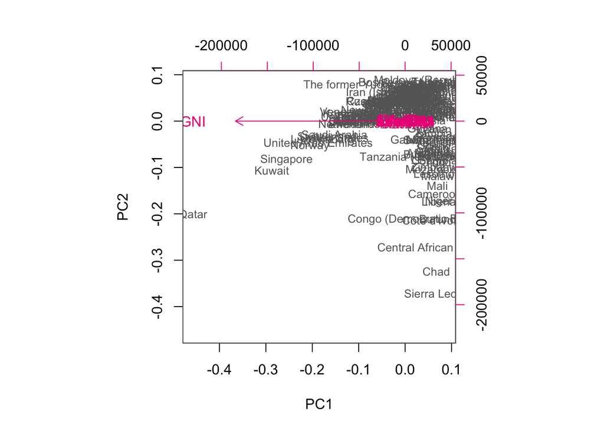

```r
biplot(pca_human, choices = 1:2, cex = c(0.8, 1), col = c("grey40", "deeppink2"))
```

### Step 3

> “Standardize the variables in the human data and repeat the above analysis”

```r
human_standardised <- scale(human)
```

```r
pca_human_standardised <- prcomp(human_standardised)
```

```r
summary(pca_human_standardised)
```

```
## Importance of components:
##                           PC1    PC2     PC3     PC4     PC5     PC6     PC7
## Standard deviation     2.0708 1.1397 0.87505 0.77886 0.66196 0.53631 0.45900
## Proportion of Variance 0.5361 0.1624 0.09571 0.07583 0.05477 0.03595 0.02634
## Cumulative Proportion  0.5361 0.6984 0.79413 0.86996 0.92473 0.96069 0.98702
##                            PC8
## Standard deviation     0.32224
## Proportion of Variance 0.01298
## Cumulative Proportion  1.00000
```

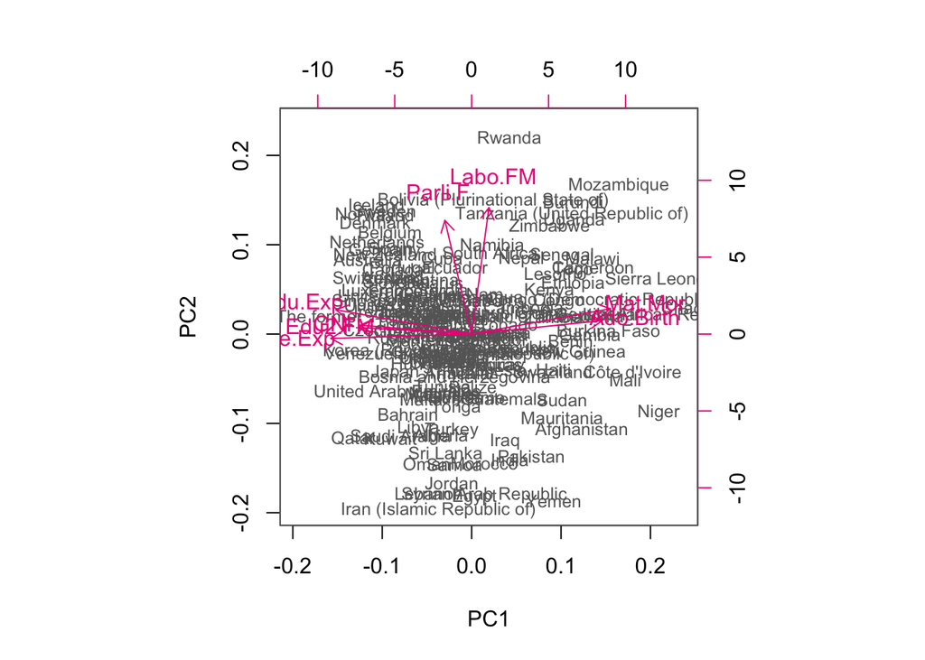

```r
biplot(pca_human_standardised, choices = 1:2, cex = c(0.8, 1), col = c("grey40", "deeppink2"))
```

> “Interpret the results of both analysis (with and without standardizing)”

*“Are the results different? Why or why not?”*

Interpreting the scaled biplot is a lot more sensible. We can see that Life Expectancy, years of educations a child can expect, also female-to-male ratio of achieving secondary education are all correlated with each other and with money, and they are negatively correlated with Maternal Mortality and teenage births. All of these variables have arrows that are close to parallel to PC1.

Whereas, women in parliament and in workforce are correlated, and close to parallel with PC2.

See more comments below.

> “Include captions (brief descriptions) in your plots”

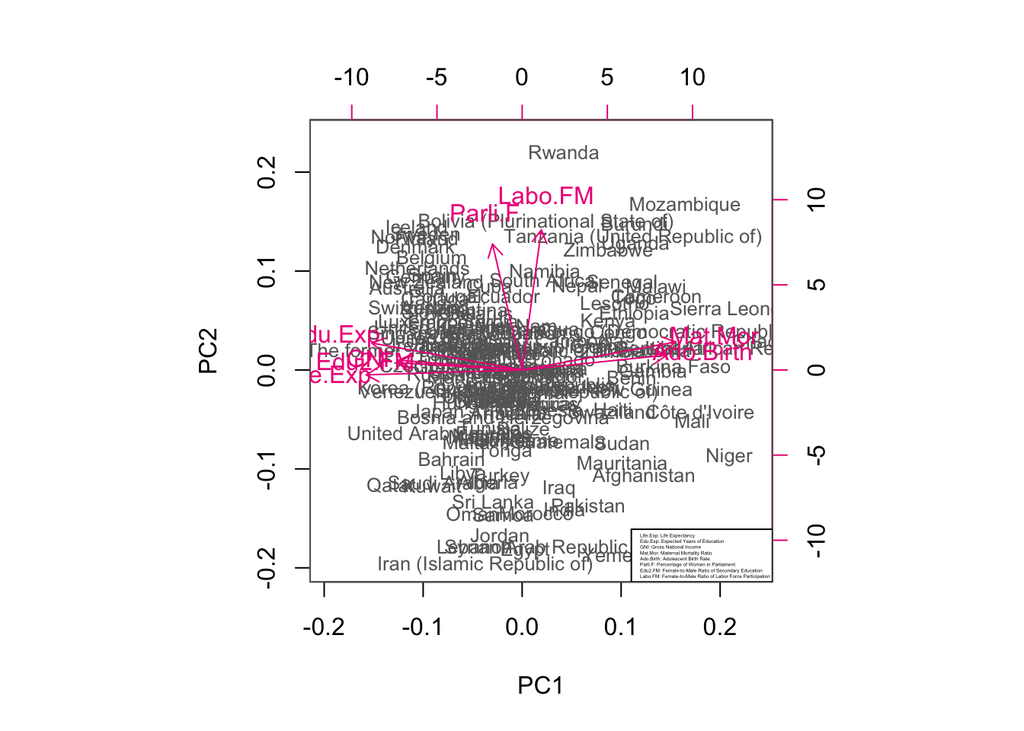

```r
biplot(pca_human_standardised, choices = 1:2, cex = c(0.8, 1), col = c("grey40", "deeppink2"))
legend("bottomright", legend = c(
"Life.Exp: Life Expectancy ",
"Edu.Exp: Expected Years of Education ",
"GNI: Gross National Income",
"Mat.Mor: Maternal Mortality Ratio",
"Ado.Birth: Adolescent Birth Rate",
"Parli.F: Percentage of Women in Parliament",
"Edu2.FM: Female-to-Male Ratio of Secondary Education",
"Labo.FM: Female-to-Male Ratio of Labor Force Participation"
), cex = 0.2)
```

### Step 4

> “Give your personal interpretations of the first two principal component dimensions based on the biplot drawn after PCA on the standardized human data”

The principal components can sometimes be hidden factors that do not directly map to a known concept, or sometimes to a very abstract quality or measure that’s hard to pin-point, and we cannot over-generalise that it’s “richness” or “goodness” or “development”. One can only make rough guesses what kinds of qualities the axes may correspond to, based on heuristics (namely generalisation from pre-loaded perception).

In the biplot, the points (labels of country names) are observations mapped along the 2 main PCs. Points close to each other share similar values as measured by the PC axes. Here, using our preconceived priors as heuristics we can gauge, ah okay, Qatar is on one side and Afghanistan on the other side, so this axis has something to do with rich vs. poor. Then you see the Nordics up there and Iran down there, you wonder if that axis has something to do with the permissiveness towards certain things, which could be bacon for all we know. Here I must apologise for my geographical ignorance that I really don’t know what it’s qualitatively and subjective like in those poorer countries who happen to be quite high up in terms of PC2. Kigali is a vibrant start-up scene with hipster coffeeshops nowadays, as rumours say, which could relate to the UK government’s interest in sending people there.

If two arrows are radially close to each other (that is, having similar clock-angles on the chart), it means the two original variables co-vary more closely – if they point the same way they co-vary positively, if they point almost 180-degree opposite ways, they co-vary negatively.

We can think of the PC axes also like the arrows, if an arrow is close to parallel with an axes, its corresponding original variable is more aligned with that PC. The size of the arrow indicates how much of a PC is explained by that original variable.

### Step 5

> “Load the tea dataset and convert its character variables to factors”

```r
tea <- read.csv("https://raw.githubusercontent.com/KimmoVehkalahti/Helsinki-Open-Data-Science/master/datasets/tea.csv", stringsAsFactors = TRUE)
```

> “Look at the structure and the dimensions of the data”

```r
str(tea)
```

```
## 'data.frame':    300 obs. of  36 variables:
##  $ breakfast       : Factor w/ 2 levels "breakfast","Not.breakfast": 1 1 2 2 1 2 1 2 1 1 ...
##  $ tea.time        : Factor w/ 2 levels "Not.tea time",..: 1 1 2 1 1 1 2 2 2 1 ...
##  $ evening         : Factor w/ 2 levels "evening","Not.evening": 2 2 1 2 1 2 2 1 2 1 ...
##  $ lunch           : Factor w/ 2 levels "lunch","Not.lunch": 2 2 2 2 2 2 2 2 2 2 ...
##  $ dinner          : Factor w/ 2 levels "dinner","Not.dinner": 2 2 1 1 2 1 2 2 2 2 ...
##  $ always          : Factor w/ 2 levels "always","Not.always": 2 2 2 2 1 2 2 2 2 2 ...
##  $ home            : Factor w/ 2 levels "home","Not.home": 1 1 1 1 1 1 1 1 1 1 ...
##  $ work            : Factor w/ 2 levels "Not.work","work": 1 1 2 1 1 1 1 1 1 1 ...
##  $ tearoom         : Factor w/ 2 levels "Not.tearoom",..: 1 1 1 1 1 1 1 1 1 2 ...
##  $ friends         : Factor w/ 2 levels "friends","Not.friends": 2 2 1 2 2 2 1 2 2 2 ...
##  $ resto           : Factor w/ 2 levels "Not.resto","resto": 1 1 2 1 1 1 1 1 1 1 ...
##  $ pub             : Factor w/ 2 levels "Not.pub","pub": 1 1 1 1 1 1 1 1 1 1 ...
##  $ Tea             : Factor w/ 3 levels "black","Earl Grey",..: 1 1 2 2 2 2 2 1 2 1 ...
##  $ How             : Factor w/ 4 levels "alone","lemon",..: 1 3 1 1 1 1 1 3 3 1 ...
```

[output cut: 22 more lines]

```r
dim(tea)
```

```
## [1] 300  36
```

> “Use View(tea) to browse its contents, and visualize the data”

```r
# View(tea)
# Run this for one's own viewing leisure
```

> “Use Multiple Correspondence Analysis (MCA) on the tea data (or a subset of columns)”

```r
library(FactoMineR)
subset_tea <- tea[, c("Tea", "How", "how", "sugar")]
mca <- MCA(subset_tea, graph = FALSE)
```

> “Interpret the results of the MCA”

```r
summary(mca)
```

```
##
## Call:
## MCA(X = subset_tea, graph = FALSE)
##
##
## Eigenvalues
##                        Dim.1   Dim.2   Dim.3   Dim.4   Dim.5   Dim.6   Dim.7
## Variance               0.338   0.292   0.272   0.261   0.242   0.227   0.208
## % of var.             16.924  14.598  13.609  13.031  12.088  11.337  10.389
## Cumulative % of var.  16.924  31.522  45.131  58.162  70.250  81.587  91.977
##                        Dim.8
## Variance               0.160
## % of var.              8.023
## Cumulative % of var. 100.000
##
## Individuals (the 10 first)
##                       Dim.1    ctr   cos2    Dim.2    ctr   cos2    Dim.3
## 1                  |  0.102  0.010  0.008 |  0.251  0.072  0.046 | -0.070
## 2                  |  0.521  0.267  0.128 |  0.730  0.609  0.251 | -0.622
## 3                  | -0.045  0.002  0.003 | -0.227  0.059  0.074 | -0.322
## 4                  | -0.625  0.385  0.534 | -0.109  0.014  0.016 | -0.130
## 5                  | -0.045  0.002  0.003 | -0.227  0.059  0.074 | -0.322
## 6                  | -0.045  0.002  0.003 | -0.227  0.059  0.074 | -0.322
## 7                  | -0.045  0.002  0.003 | -0.227  0.059  0.074 | -0.322
## 8                  |  0.521  0.267  0.128 |  0.730  0.609  0.251 | -0.622
## 9                  |  0.057  0.003  0.002 |  0.343  0.134  0.063 | -0.320
## 10                 |  0.946  0.881  0.533 |  0.104  0.012  0.006 |  0.100
##                       ctr   cos2
## 1                   0.006  0.004 |
## 2                   0.474  0.182 |
## 3                   0.127  0.149 |
## 4                   0.021  0.023 |
## 5                   0.127  0.149 |
## 6                   0.127  0.149 |
## 7                   0.127  0.149 |
## 8                   0.474  0.182 |
## 9                   0.125  0.055 |
## 10                  0.012  0.006 |
##
## Categories (the 10 first)
```

[output cut: 14 more lines]

```
## green               -9.054 |  -0.739   5.516   0.067  -4.492 |
## alone              -11.217 |  -0.096   0.545   0.017  -2.251 |
## lemon                1.796 |   2.116  45.221   0.553  12.861 |
## milk                 7.283 |  -0.846  13.801   0.190  -7.541 |
## other               10.677 |   0.234   0.150   0.002   0.711 |
## tea bag              2.766 |  -0.439  10.042   0.252  -8.685 |
## tea bag+unpackaged   0.917 |   0.316   2.869   0.045   3.688 |
## unpackaged          -5.526 |   1.250  17.214   0.213   7.980 |
##
## Categorical variables (eta2)
##                      Dim.1 Dim.2 Dim.3
## Tea                | 0.543 0.382 0.070 |
## How                | 0.154 0.667 0.650 |
## how                | 0.201 0.103 0.328 |
## sugar              | 0.456 0.016 0.040 |
```

> “Draw the variable biplot of the analysis”

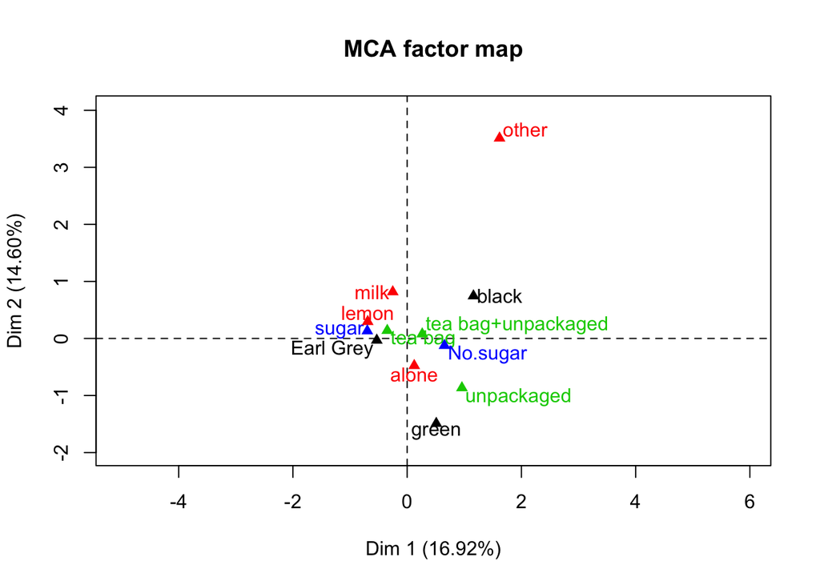

```r
plot(mca, invisible=c("ind"), graph.type = "classic", habillage = "quali")
```

> “Comment on the output of the plots”

I can comment that it is indeed news to me that Earl Grey can also go with lemon. It’s quite expected that green tea does not go with milk like Earl Grey or black tea does, but I’m curious to find out what that “other” category might entail. Honey, perhaps? Also it’s curious what tea bag plus unpackaged means, perhaps it’s sometimes this sometimes that, but you can also see that for green tea drinkers, it’s more easily a snobbery thing where drinking loose leaves is perceived as somehow superior than just dunking a pre-manufactured bag in hot water.